# Hepatitis C Dataset: Comprehensive Analysis - BIOS 611 Final Project

Yuting Sun

Nov 30, 2025

# 1. Introduction

## 1.1 Project Overview

This project presents a comprehensive analysis of the Hepatitis C dataset, exploring clinical variables to understand disease patterns and develop predictive models. The analysis follows a data science workflow from initial exploration through advanced modeling.

## 1.2 Research Questions

The analysis addresses several key questions:

1. **Data Quality**: What is the structure and quality of the dataset? Are there missing values or anomalies?
2. **Feature Relationships**: How do different clinical markers correlate with each other?
3. **Dimensionality**: Can we reduce the feature space while preserving important information?
4. **Prediction**: Can we build accurate models to classify Hepatitis C categories?
5. **Feature Importance**: Which clinical markers are most important for prediction?

# 2. Initial Data Exploration

## 2.1 Loading Libraries and Data

```r
# Load all required libraries
library(tidyverse)    # Data manipulation & plotting
library(corrplot)     # Correlation matrices
library(naniar)       # Missing value visualization
library(GGally)       # Pair plots
library(factoextra)   # PCA visualization
library(caret)        # Machine learning workflow
library(glmnet)       # Lasso/Ridge regression
library(pROC)         # ROC curves
library(randomForest) # Random Forest model
library(MASS)         # LDA model
library(reshape2)     # Data reshaping
# Set plotting theme
theme_set(theme_minimal(base_size = 12))
```

```r
# Load the dataset
data <- read.csv("data/hcvdat0.csv")

head(data)
```

```
##   X      Category Age Sex  ALB  ALP  ALT  AST  BIL   CHE CHOL CREA  GGT PROT
## 1 1 0=Blood Donor  32   m 38.5 52.5  7.7 22.1  7.5  6.93 3.23  106 12.1 69.0
## 2 2 0=Blood Donor  32   m 38.5 70.3 18.0 24.7  3.9 11.17 4.80   74 15.6 76.5
## 3 3 0=Blood Donor  32   m 46.9 74.7 36.2 52.6  6.1  8.84 5.20   86 33.2 79.3
## 4 4 0=Blood Donor  32   m 43.2 52.0 30.6 22.6 18.9  7.33 4.74   80 33.8 75.7
## 5 5 0=Blood Donor  32   m 39.2 74.1 32.6 24.8  9.6  9.15 4.32   76 29.9 68.7
## 6 6 0=Blood Donor  32   m 41.6 43.3 18.5 19.7 12.3  9.92 6.05  111 91.0 74.0
```

## 2.2 Understanding the Data Structure

```r
str(data)
```

```
## 'data.frame':    615 obs. of  14 variables:
##  $ X       : int  1 2 3 4 5 6 7 8 9 10 ...
##  $ Category: chr  "0=Blood Donor" "0=Blood Donor" "0=Blood Donor" "0=Blood Donor" ...
##  $ Age     : int  32 32 32 32 32 32 32 32 32 32 ...
##  $ Sex     : chr  "m" "m" "m" "m" ...
##  $ ALB     : num  38.5 38.5 46.9 43.2 39.2 41.6 46.3 42.2 50.9 42.4 ...
##  $ ALP     : num  52.5 70.3 74.7 52 74.1 43.3 41.3 41.9 65.5 86.3 ...
##  $ ALT     : num  7.7 18 36.2 30.6 32.6 18.5 17.5 35.8 23.2 20.3 ...
##  $ AST     : num  22.1 24.7 52.6 22.6 24.8 19.7 17.8 31.1 21.2 20 ...
##  $ BIL     : num  7.5 3.9 6.1 18.9 9.6 12.3 8.5 16.1 6.9 35.2 ...
##  $ CHE     : num  6.93 11.17 8.84 7.33 9.15 ...
##  $ CHOL    : num  3.23 4.8 5.2 4.74 4.32 6.05 4.79 4.6 4.1 4.45 ...
##  $ CREA    : num  106 74 86 80 76 111 70 109 83 81 ...
##  $ GGT     : num  12.1 15.6 33.2 33.8 29.9 91 16.9 21.5 13.7 15.9 ...
##  $ PROT    : num  69 76.5 79.3 75.7 68.7 74 74.5 67.1 71.3 69.9 ...
```

```r
dim(data)
```

```
## [1] 615  14
```

```r
summary(data)
```

```
##        X           Category              Age            Sex
##  Min.   :  1.0   Length:615         Min.   :19.00   Length:615
##  1st Qu.:154.5   Class :character   1st Qu.:39.00   Class :character
##  Median :308.0   Mode  :character   Median :47.00   Mode  :character
##  Mean   :308.0                      Mean   :47.41
##  3rd Qu.:461.5                      3rd Qu.:54.00
##  Max.   :615.0                      Max.   :77.00
##
##       ALB             ALP              ALT              AST
##  Min.   :14.90   Min.   : 11.30   Min.   :  0.90   Min.   : 10.60
##  1st Qu.:38.80   1st Qu.: 52.50   1st Qu.: 16.40   1st Qu.: 21.60
##  Median :41.95   Median : 66.20   Median : 23.00   Median : 25.90
##  Mean   :41.62   Mean   : 68.28   Mean   : 28.45   Mean   : 34.79
##  3rd Qu.:45.20   3rd Qu.: 80.10   3rd Qu.: 33.08   3rd Qu.: 32.90
##  Max.   :82.20   Max.   :416.60   Max.   :325.30   Max.   :324.00
##  NA's   :1       NA's   :18       NA's   :1
##       BIL             CHE              CHOL            CREA
##  Min.   :  0.8   Min.   : 1.420   Min.   :1.430   Min.   :   8.00
##  1st Qu.:  5.3   1st Qu.: 6.935   1st Qu.:4.610   1st Qu.:  67.00
##  Median :  7.3   Median : 8.260   Median :5.300   Median :  77.00
##  Mean   : 11.4   Mean   : 8.197   Mean   :5.368   Mean   :  81.29
##  3rd Qu.: 11.2   3rd Qu.: 9.590   3rd Qu.:6.060   3rd Qu.:  88.00
##  Max.   :254.0   Max.   :16.410   Max.   :9.670   Max.   :1079.10
##                                   NA's   :10
##       GGT              PROT
##  Min.   :  4.50   Min.   :44.80
##  1st Qu.: 15.70   1st Qu.:69.30
##  Median : 23.30   Median :72.20
##  Mean   : 39.53   Mean   :72.04
##  3rd Qu.: 40.20   3rd Qu.:75.40
##  Max.   :650.90   Max.   :90.00
##                   NA's   :1
```

**Initial Observations:** - This dataset contains 615 rows and 14 columns - Most of the variables are clinical variable - Need to check for missing values

# 3. Data Quality Assessment

## 3.1 Missing Values Analysis

```r
colSums(is.na(data))
```

```
##        X Category      Age      Sex      ALB      ALP      ALT      AST
##        0        0        0        0        1       18        1        0
##      BIL      CHE     CHOL     CREA      GGT     PROT
##        0        0       10        0        0        1
```

```r
missing_by_category <- data %>%
  group_by(Category) %>%
  summarise(
    n_total = n(),
    n_with_missing = sum(rowSums(is.na(across(Age:PROT))) > 0),
    pct_missing = round(n_with_missing / n_total * 100, 1),
    ALB_missing = sum(is.na(ALB)),
    ALP_missing = sum(is.na(ALP)),
    ALT_missing = sum(is.na(ALT)),
    CHOL_missing = sum(is.na(CHOL)),
    PROT_missing = sum(is.na(PROT)),

    # for the columns only have one missing value
    single_missing = sum(rowSums(is.na(across(Age:PROT))) == 1),
    # for the columns have more than one missing values
    multi_missing = sum(rowSums(is.na(across(Age:PROT))) >= 2)
  )

print(missing_by_category)
```

```
## # A tibble: 5 × 11
##   Category            n_total n_with_missing pct_missing ALB_missing ALP_missing
##   <chr>                 <int>          <int>       <dbl>       <int>       <int>
## 1 0=Blood Donor           533              7         1.3           0           0
## 2 0s=suspect Blood D…       7              0         0             0           0
## 3 1=Hepatitis              24              4        16.7           0           3
## 4 2=Fibrosis               21              9        42.9           0           9
## 5 3=Cirrhosis              30              6        20             1           6
## # ℹ 5 more variables: ALT_missing <int>, CHOL_missing <int>,
## #   PROT_missing <int>, single_missing <int>, multi_missing <int>
```

**3.2 Imputation Strategy**

```r
# Impute using median for each category
data_clean <- data %>%
  mutate(na_count = rowSums(is.na(dplyr::select(., Age:PROT)))) %>%
  filter(na_count < 2) %>%
  group_by(Category) %>%
  mutate(across(Age:PROT, ~ifelse(is.na(.), median(., na.rm = TRUE), .))) %>%
  ungroup() %>%
  dplyr::select(-na_count) %>%
  filter(Category != "0s=suspect Blood Donor")
```

**3.3 Creating Analysis Datasets:** Created two analysis datasets: - Screening Dataset: Binary classification (Healthy vs Disease)

```r
# Dataset A: Screening
data_screening <- data_clean %>%
  mutate(Disease = ifelse(Category == "0=Blood Donor", "Healthy", "Disease")) %>%
  mutate(Disease = factor(Disease, levels = c("Healthy", "Disease")),
         Sex = factor(Sex))
```

- Staging Dataset: Multi-class classification (Hepatitis, Fibrosis, Cirrhosis)

```r
# Dataset B: Staging
data_staging <- data_clean %>%
  filter(Category != "0=Blood Donor") %>%
  mutate(Stage = case_when(
    Category == "1=Hepatitis" ~ "Hepatitis",
    Category == "2=Fibrosis" ~ "Fibrosis",
    Category == "3=Cirrhosis" ~ "Cirrhosis"
  )) %>%
  mutate(Stage = factor(Stage, levels = c("Hepatitis", "Fibrosis", "Cirrhosis")),
         Sex = factor(Sex))
```

# 4. Exploratory Data Analysis (EDA)

**4.1 Correlation Matrix**

```r
biomarkers <- c("Age", "ALB", "ALP", "ALT", "AST", "BIL", "CHE", "CHOL", "CREA", "GGT", "PROT")
cat("Saving 01_correlation_matrix.png ...\n")
```

```
## Saving 01_correlation_matrix.png ...
```

```r
## Saving 01_correlation_matrix.png ...
png(file.path('figures/', "01_correlation_matrix.png"), width = 800, height = 800)

numeric_data <- data_clean %>% dplyr::select(all_of(biomarkers))
cor_matrix <- cor(numeric_data)
corrplot(cor_matrix, method = "color", type = "upper", tl.col = "black",
         title = "Correlation Matrix of Variables", mar = c(0,0,2,0))
dev.off()
```

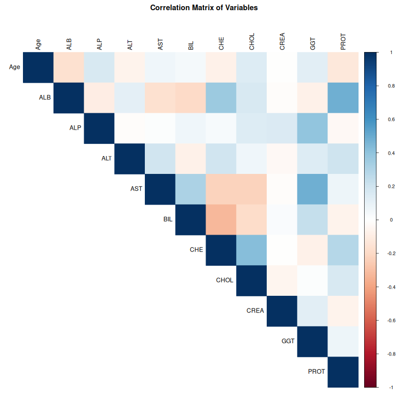

```r
knitr::include_graphics("figures/01_correlation_matrix.png")
```

- PROT & ALB, CGT & AST, CHE & CHOL have highest positive correlations
- BIL & ALB, BIL & CHE, AST & CHE seems like have highest negative correlations

**4.2 Boxplots (ggplot)**

```r
cat("Saving 02_biomarker_boxplots.png ...\n")
```

```
## Saving 02_biomarker_boxplots.png ...
```

```r
## Saving 02_biomarker_boxplots.png ...
data_long <- data %>%
  dplyr::select(Category, all_of(biomarkers)) %>%
  pivot_longer(cols = all_of(biomarkers), names_to = "Biomarker", values_to = "Value")


p_box <- ggplot(data_long, aes(x = Category, y = Value, fill = Category)) +
  geom_boxplot() +
  facet_wrap(~Biomarker, scales = "free_y",ncol = 2) +
  labs(title = "Biomarker Across Disease Categories", x = "Category", y = "Value") +
  theme_minimal()
  theme(axis.text.x = element_text(angle = 45, hjust = 1),
        legend.position = "none")
```

[output not shown]

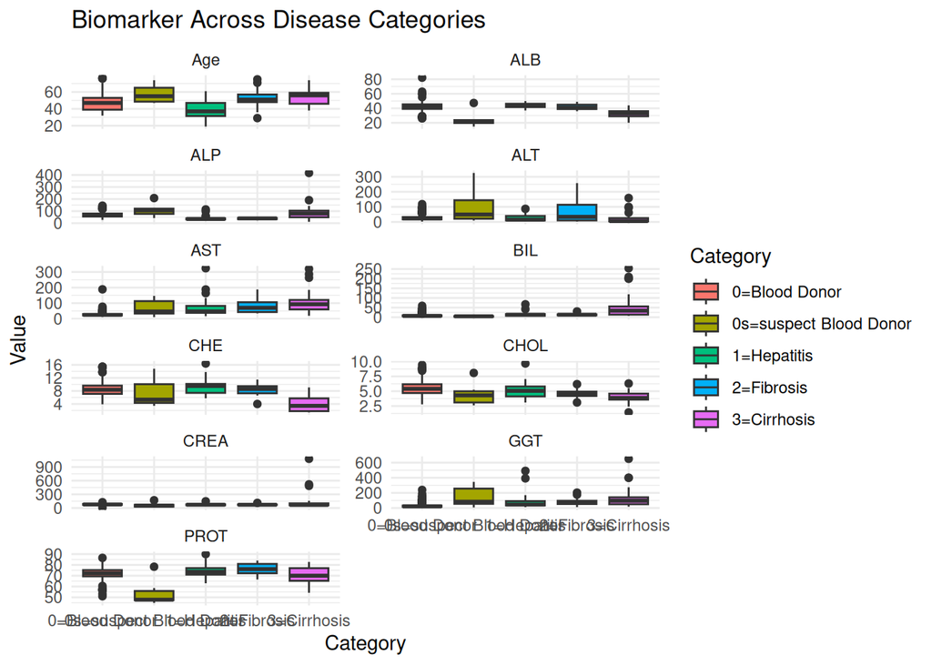

```r
print(p_box)
```

```r
ggsave(file.path('figures/', "02_biomarker_boxplots.png"), p_box, width = 10, height = 6)
```

**Key Observations:**

- Suspect Blood Donors (0s) Show Ambiguous Patterns: The suspect blood donor group displays biomarker levels that overlap significantly with both healthy donors and disease categories
- Biomarker Differences:AST Shows an increasing trend from healthy → hepatitis → fibrosis → cirrhosis, but most of the variables did not show clear changing trend.

```r
cat("Saving 03_biomarker_boxplots_screening.png ...\n")
```

```
## Saving 03_biomarker_boxplots_screening.png ...
```

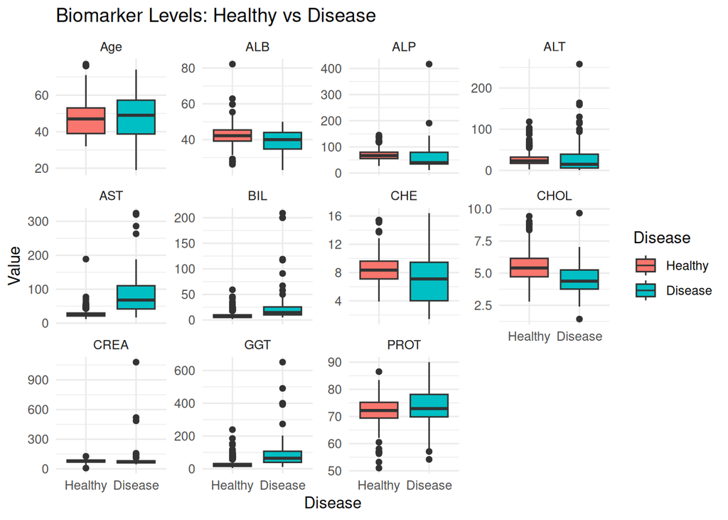

```r
## Saving 03_biomarker_boxplots_screening.png ...
data_long_screening <- data_screening %>%
  dplyr::select(Disease, all_of(biomarkers)) %>%
  pivot_longer(cols = all_of(biomarkers), names_to = "Biomarker", values_to = "Value")

p_box <- ggplot(data_long_screening, aes(x = Disease, y = Value, fill = Disease)) +
  geom_boxplot() +
  facet_wrap(~Biomarker, scales = "free_y") +
  labs(title = "Biomarker Levels: Healthy vs Disease", y = "Value") +
  theme_minimal()

print(p_box)
```

```r
ggsave(file.path('figures/', "03_biomarker_boxplots_screening.png"), p_box, width = 10, height = 6)
```

- Clear Discrimination Variables: AST,BIL,CGT
- Seems more clear than the original data, the new caterogy of disease vs healthy may easier to analyse

```r
cat("Saving 04_biomarker_boxplots_staging.png ...\n")
```

```
## Saving 04_biomarker_boxplots_staging.png ...
```

```r
## Saving 04_biomarker_boxplots_staging.png ...
data_long_staging <- data_staging %>%
  dplyr::select(Category, all_of(biomarkers)) %>%
  pivot_longer(cols = all_of(biomarkers), names_to = "Biomarker", values_to = "Value")


p_box <- ggplot(data_long_staging, aes(x = Category, y = Value, fill = Category)) +
  geom_boxplot() +
  facet_wrap(~Biomarker, scales = "free_y",ncol = 2) +
  labs(title = "Biomarker Across Disease Categories", x = "Category", y = "Value") +
  theme_minimal()
  theme(axis.text.x = element_text(angle = 45, hjust = 1),
        legend.position = "none")
```

[output not shown]

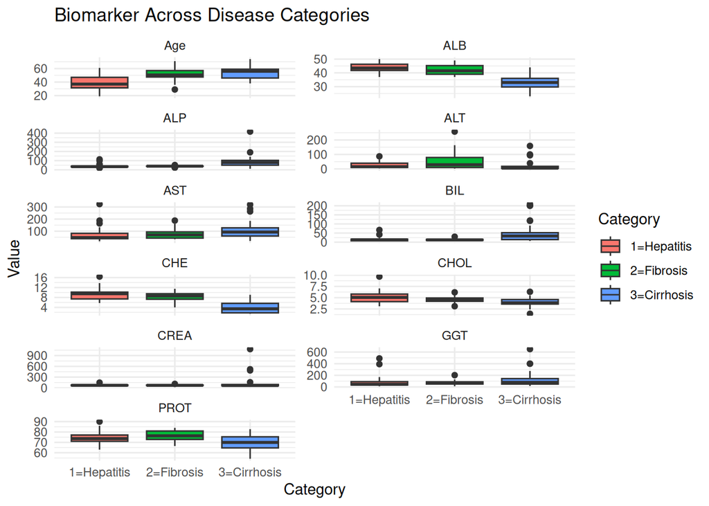

```r
print(p_box)
```

```r
ggsave(file.path('figures/', "04_biomarker_boxplots_staging.png"), p_box, width = 10, height = 6)
```

- No clear pattern but have the value to explore

# 5. Screening Task (PCA and Lasso)

## 5.1 PCA

### 5.1.1 PCA on screening data using all 11 variables

Purpose: Explore the intrinsic structure of the 11-biomarker dataset and assess separability between healthy and diseased groups.

```r
cat("Saving 05_pca_screening_all.png ...\n")
```

```
## Saving 05_pca_screening_all.png ...
```

```r
pca_data <- data_screening %>% dplyr::select(all_of(biomarkers)) %>% scale()
head(pca_data)
```

```
##           Age         ALB        ALP        ALT        AST         BIL
## [1,] -1.53296 -0.63040905 -0.5876245 -0.9397181 -0.3698995 -0.20755741
## [2,] -1.53296 -0.63040905  0.1161029 -0.4474103 -0.2894677 -0.41706755
## [3,] -1.53296  0.94352305  0.2900580  0.4224927  0.5736278 -0.28903357
## [4,] -1.53296  0.25024343 -0.6073921  0.1548303 -0.3544319  0.45589138
## [5,] -1.53296 -0.49924804  0.2663369  0.2504240 -0.2863742 -0.08534316
## [6,] -1.53296 -0.04955316 -0.9513488 -0.4235119 -0.4441443  0.07178945
##             CHE       CHOL        CREA         GGT       PROT
## [1,] -0.5983972 -1.9311237  0.49144547 -0.49742556 -0.6573362
## [2,]  1.3688310 -0.5203849 -0.15094088 -0.42951375  0.8631119
## [3,]  0.2877834 -0.1609610  0.08995400 -0.08801435  1.4307459
## [4,] -0.4128096 -0.5742985 -0.03049344 -0.07637232  0.7009308
## [5,]  0.4316138 -0.9516936 -0.11079174 -0.15204549 -0.7181542
## [6,]  0.7888699  0.6028148  0.59181834  1.03350071  0.3562959
```

```r
pca_res <- prcomp(pca_data, center = FALSE, scale. = FALSE)
summary(pca_res)
```

```
## Importance of components:
##                           PC1    PC2    PC3     PC4     PC5    PC6    PC7
## Standard deviation     1.5329 1.3313 1.2062 1.03887 0.96113 0.8843 0.8358
## Proportion of Variance 0.2136 0.1611 0.1323 0.09811 0.08398 0.0711 0.0635
## Cumulative Proportion  0.2136 0.3748 0.5070 0.60514 0.68911 0.7602 0.8237
##                            PC8     PC9    PC10   PC11
## Standard deviation     0.78370 0.70872 0.68767 0.5915
## Proportion of Variance 0.05584 0.04566 0.04299 0.0318
## Cumulative Proportion  0.87954 0.92521 0.96820 1.0000
```

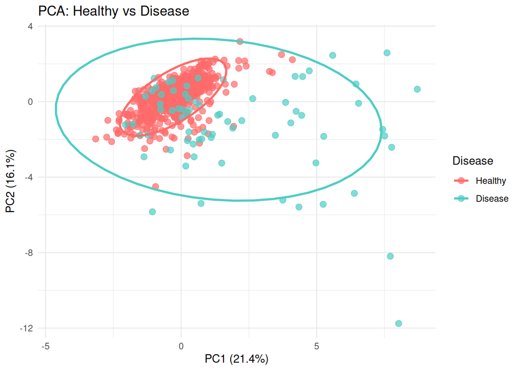

```r
pca_scores <- as.data.frame(pca_res$x)
pca_scores$Disease <- data_screening$Disease


p_pca <- ggplot(pca_scores, aes(x = PC1, y = PC2, color = Disease)) +
  geom_point(alpha = 0.7, size = 2.5) +
  stat_ellipse(level = 0.95, size = 1) +
  scale_color_manual(values = c("Healthy" = "#FF6B6B", "Disease" = "#4ECDC4")) +
  labs(title = "PCA: Healthy vs Disease",
       x = paste0("PC1 (", round(summary(pca_res)$importance[2,1]*100, 1), "%)"),
       y = paste0("PC2 (", round(summary(pca_res)$importance[2,2]*100, 1), "%)")) +
  theme_minimal() +
  theme(legend.position = "right")
print(p_pca)
```

```r
ggsave(file.path('figures/', "05_pca_screening_all.png"), p_pca, width = 8, height = 6)
```

### 5.1.2 PCA on screening data using select key variables

```r
# Core biomarkers covering liver synthesis (ALB, CHE, CHOL), damage (ALT, AST, GGT), and excretion (BIL)
key_biomarkers <- c("ALB", "ALT", "AST", "BIL", "CHE", "GGT", "CHOL")
cat("Saving 06_pca_screening_key.png ...\n")
```

```
## Saving 06_pca_screening_key.png ...
```

```r
pca_key_data <- data_screening %>% dplyr::select(all_of(key_biomarkers)) %>% scale()
head(pca_key_data)
```

```
##              ALB        ALT        AST         BIL        CHE         GGT
## [1,] -0.63040905 -0.9397181 -0.3698995 -0.20755741 -0.5983972 -0.49742556
## [2,] -0.63040905 -0.4474103 -0.2894677 -0.41706755  1.3688310 -0.42951375
## [3,]  0.94352305  0.4224927  0.5736278 -0.28903357  0.2877834 -0.08801435
## [4,]  0.25024343  0.1548303 -0.3544319  0.45589138 -0.4128096 -0.07637232
## [5,] -0.49924804  0.2504240 -0.2863742 -0.08534316  0.4316138 -0.15204549
## [6,] -0.04955316 -0.4235119 -0.4441443  0.07178945  0.7888699  1.03350071
##            CHOL
## [1,] -1.9311237
## [2,] -0.5203849
## [3,] -0.1609610
## [4,] -0.5742985
## [5,] -0.9516936
## [6,]  0.6028148
```

```r
pca_key_res <- prcomp(pca_key_data, center = FALSE, scale. = FALSE)
summary(pca_key_res)
```

```
## Importance of components:
##                           PC1    PC2    PC3    PC4     PC5     PC6    PC7
## Standard deviation     1.4770 1.2166 0.9548 0.8997 0.82084 0.70742 0.6657
## Proportion of Variance 0.3116 0.2114 0.1302 0.1157 0.09625 0.07149 0.0633
## Cumulative Proportion  0.3116 0.5231 0.6533 0.7690 0.86521 0.93670 1.0000
```

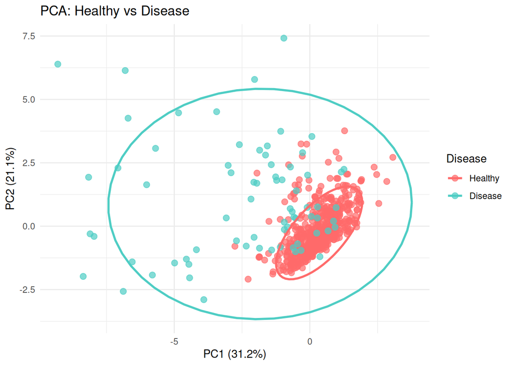

```r
pca_key_scores <- as.data.frame(pca_key_res$x)
pca_key_scores$Disease <- data_screening$Disease


p_key_pca <- ggplot(pca_key_scores, aes(x = PC1, y = PC2, color = Disease)) +
  geom_point(alpha = 0.7, size = 2.5) +
  stat_ellipse(level = 0.95, size = 1) +
  scale_color_manual(values = c("Healthy" = "#FF6B6B", "Disease" = "#4ECDC4")) +
  labs(title = "PCA: Healthy vs Disease",
       x = paste0("PC1 (", round(summary(pca_key_res)$importance[2,1]*100, 1), "%)"),
       y = paste0("PC2 (", round(summary(pca_key_res)$importance[2,2]*100, 1), "%)")) +
  theme_minimal() +
  theme(legend.position = "right")
print(p_key_pca)
```

```r
ggsave(file.path('figures/', "06_pca_screening_key.png"), p_key_pca, width = 8, height = 6)
```

*Key Observations:*

The first two principal components (PC1: 31.2%, PC2: 21.1%) capture 52.3% of the total variance Healthy individuals (red) form a tight, concentrated cluster, indicating consistent biomarker profiles Diseased individuals (blue) show greater dispersion but demonstrate clear separation from the healthy cluster This spatial separation validates the feasibility of classification using biomarker data

*Biplot*

```
## Ignoring unknown labels:
## • linetype : "Status"
```

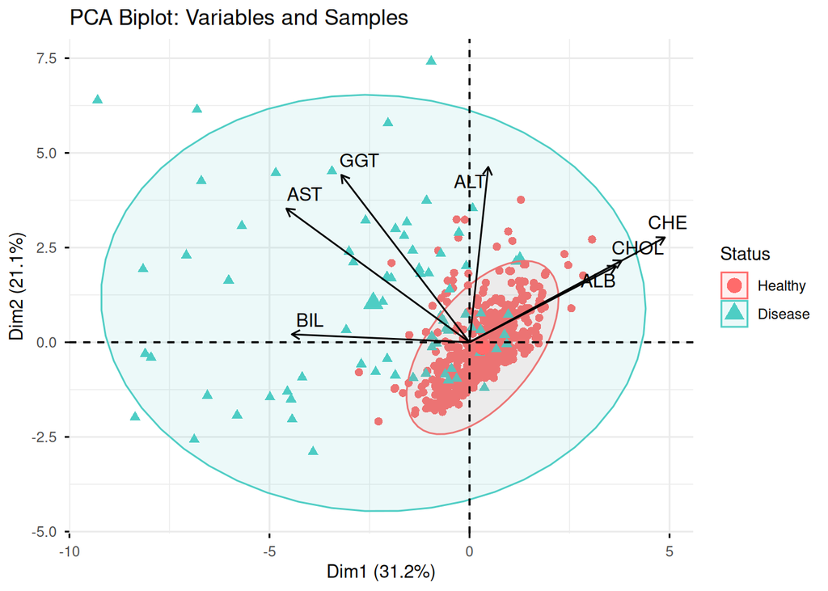

```r
p_biplot <- fviz_pca_biplot(pca_key_res,
                geom.ind = "point",
                col.ind = data_screening$Disease,
                pointsize = 2,
                palette = c("#FF6B6B", "#4ECDC4"),
                addEllipses = TRUE,
                geom.var = c("arrow", "text"),
                col.var = "black",


                repel = TRUE,
                title = "PCA Biplot: Variables and Samples",
                legend.title = "Status"
)

print(p_biplot)
```

```r
ggsave(file.path('figures/', "07_pca_biplot_advanced.png"), p_biplot, width = 10, height = 7)
```

```
## Ignoring unknown labels:
## • linetype : "Status"
```

*PCA Results Interpretation*

- The PCA Biplot demonstrates a clear separation between the Healthy and Disease populations.
- The Healthy group (red) is characterized by higher levels of ALB, CHE, and CHOL, which are positively correlated and indicate preserved liver function.
- Conversely, the Disease group (teal) is characterized by elevated levels of AST, GGT, and BIL, indicating liver injury.
- The wide scattering of the Disease samples implies varied disease progression, whereas the healthy controls show high homogeneity

*Variables Correlation Circle*

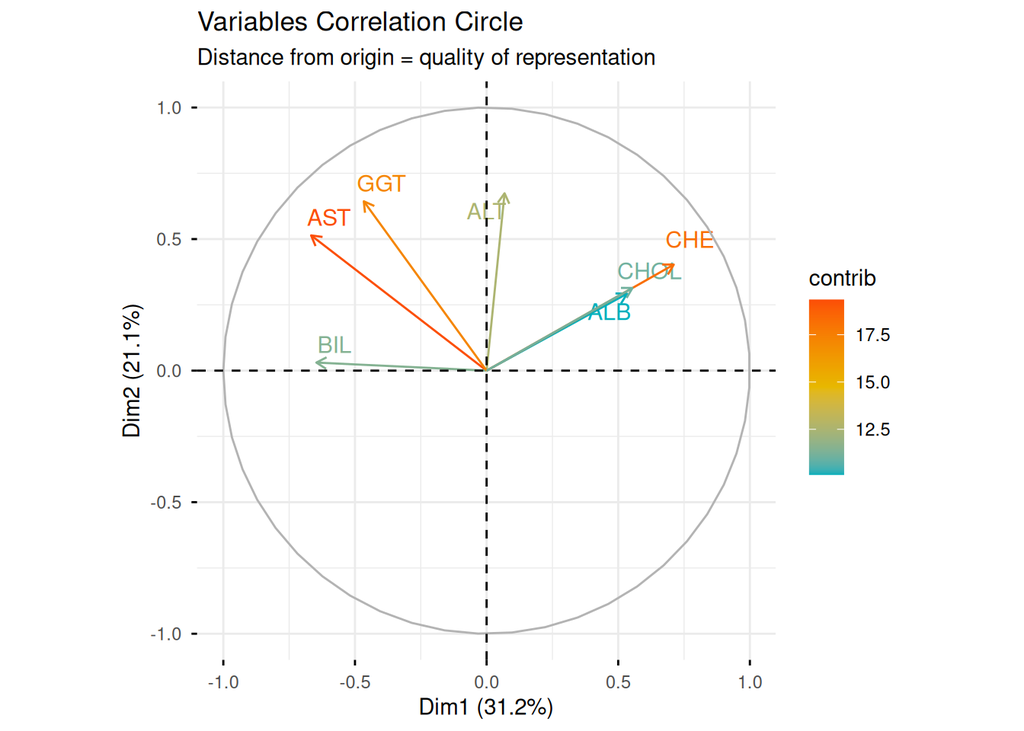

```r
p_corr_circle <- fviz_pca_var(pca_key_res,
                 col.var = "contrib",
                 gradient.cols = c("#00AFBB", "#E7B800", "#FC4E07"),
                 repel = TRUE,
                 title = "Variables Correlation Circle",
                 subtitle = "Distance from origin = quality of representation"
)
print(p_corr_circle)
```

```r
ggsave(file.path('figures/', "08_pca_var_circle.png"), p_corr_circle, width = 8, height = 8)
```

-The Correlation Circle further highlights that AST and GGT are strongly correlated with each other and inversely correlated with Albumin and Choline Esterase.

*Biological Interpretation:* Liver synthesis markers (ALB, CHE, CHOL) point toward the healthy cluster → these markers are higher in healthy individuals, reflecting normal liver synthetic function Liver damage markers (AST, GGT, BIL) point toward the disease cluster → these markers are elevated in disease, reflecting hepatocellular injury and impaired metabolism This pattern aligns with the pathophysiology of liver disease: progressive loss of synthetic function coupled with increased release of intracellular enzymes

*Conclusion:* PCA reveals that healthy and diseased states occupy distinct regions in the biomarker space, with the separation driven by complementary markers of liver synthesis and damage.

## 5.2 Lasso and Logistic Regression

### 5.2.1 Lasso

```r
x_vars <- model.matrix(Disease ~ Age + Sex + ALB + ALP + ALT + AST + BIL + CHE + CHOL + CREA + GGT + PROT,
                       data = data_screening)[, -1]
y_var <- ifelse(data_screening$Disease == "Disease", 1, 0)

set.seed(123)
train_idx <- createDataPartition(y_var, p = 0.75, list = FALSE)
x_train <- x_vars[train_idx, ]; y_train <- y_var[train_idx]
x_test <- x_vars[-train_idx, ]; y_test <- y_var[-train_idx]
cv_lasso <- cv.glmnet(x_train, y_train, alpha = 1, family = "binomial", type.measure = "auc")

cat("Saving 09_lasso_cv.png ...\n")
```

```
## Saving 09_lasso_cv.png ...
```

```r
png(file.path('figures/', "09_lasso_cv.png"), width = 800, height = 600)
plot(cv_lasso)
title("Lasso Cross-Validation (AUC)", line = 2.5)
dev.off()
```

```r
best_lambda <- cv_lasso$lambda.1se
final_model <- glmnet(x_train, y_train, alpha = 1,
                      lambda = best_lambda, family = "binomial")
test_pred <- predict(final_model, newx = x_test, type = "response")
test_auc <- roc(y_test, test_pred)$auc
cat("Test AUC:", test_auc, "\n")
```

```
## Test AUC: 0.9300926
```

```r
coef(final_model)
```

```
## 13 x 1 sparse Matrix of class "dgCMatrix"
##                        s0
## (Intercept) -2.9683080676
## Age          .
## Sexm         .
## ALB          .
## ALP          .
## ALT          .
## AST          0.0245464432
## BIL          0.0017719736
## CHE          .
## CHOL         .
## CREA         .
## GGT          0.0009955502
## PROT         .
```

*Key Findings:*

- Model Performance: The final model achieved an AUC of 0.930 on the test set, demonstrating strong discriminative ability between disease and healthy individuals.
- Feature Selection: Out of 12 candidate predictors, Lasso identified only 3 significant biomarkers: AST (Aspartate Aminotransferase): β = 0.0245 BIL (Bilirubin): β = 0.0018 GGT (Gamma-Glutamyl Transferase): β = 0.0010

### 5.2.2 Logistic Regression

```r
# Using the three selected variables
final_vars <- c("AST", "BIL", "GGT")
final_data <- data_screening[, c("Disease", final_vars)]

# Logistic Regression
final_model <- glm(Disease ~ AST + BIL + GGT,
                   data = final_data,
                   family = binomial)
summary(final_model)
```

```
##
## Call:
## glm(formula = Disease ~ AST + BIL + GGT, family = binomial, data = final_data)
##
## Coefficients:
##              Estimate Std. Error z value Pr(>|z|)
## (Intercept) -7.061966   0.649956 -10.865  < 2e-16 ***
## AST          0.083659   0.013227   6.325 2.53e-10 ***
## BIL          0.072973   0.022744   3.208  0.00133 **
## GGT          0.019097   0.004723   4.043 5.27e-05 ***
## ---
## Signif. codes:  0 '***' 0.001 '**' 0.01 '*' 0.05 '.' 0.1 ' ' 1
##
## (Dispersion parameter for binomial family taken to be 1)
##
##     Null deviance: 441.58  on 604  degrees of freedom
## Residual deviance: 189.87  on 601  degrees of freedom
## AIC: 197.87
##
## Number of Fisher Scoring iterations: 7
```

```r
exp(coef(final_model))
```

```
##  (Intercept)          AST          BIL          GGT
## 0.0008570914 1.0872581628 1.0757018524 1.0192800258
```

```r
exp(confint(final_model))
```

[output not shown]

```
##                    2.5 %      97.5 %
## (Intercept) 0.0002150072 0.002774349
## AST         1.0611226463 1.117756161
## BIL         1.0270004495 1.123974896
## GGT         1.0100348364 1.029102316
```

```r
# Prediction on testing dataset
test_data <- final_data[-train_idx, ]
test_pred <- predict(final_model, test_data, type = "response")
test_auc <- roc(test_data$Disease, test_pred)$auc
```

*Logistic Regression with Selected Features*

- Following Lasso feature selection, a standard logistic regression model was fitted using the three identified biomarkers (AST, BIL, GGT). All three predictors demonstrated highly significant associations with hepatitis C disease status:
  - AST (OR = 1.087, 95% CI [1.061, 1.118], p < 0.001): Each 1 U/L increase in AST was associated with an 8.7% increase in disease odds, confirming its role as the strongest predictor.
  - BIL (OR = 1.076, 95% CI [1.027, 1.124], p = 0.001): Elevated bilirubin levels significantly contributed to disease risk, with a 7.6% odds increase per unit.
  - GGT (OR = 1.019, 95% CI [1.010, 1.029], p < 0.001): GGT showed a modest but significant effect (1.9% odds increase per unit).
- The model demonstrated excellent fit, reducing deviance by 57% compared to the null model (AIC = 197.87). These results validate the Lasso-selected features and provide interpretable effect sizes for clinical application.

```r
# Evaluate logistic regression model on test set
test_pred_glm <- predict(final_model, newdata = data_screening[-train_idx, ],
                         type = "response")

# AUC
library(pROC)
roc_glm <- roc(y_test, test_pred_glm)
test_auc_glm <- auc(roc_glm)

cat("Logistic Regression Test AUC:", test_auc_glm, "\n")
```

```
## Logistic Regression Test AUC: 0.9305556
```

```r
# Plot ROC
png(file.path('figures/', "10_roc_comparison.png"), width = 800, height = 600)
plot(roc_glm, col = "blue", lwd = 2, main = "ROC Curve Comparison")
legend("bottomright",
       legend = c(paste("Logistic Regression (AUC =", round(test_auc_glm, 3), ")"),
                  paste("Lasso (AUC = 0.930)")),
       col = c("blue", "red"), lwd = 2)
dev.off()
```

```r
pred_class <- ifelse(test_pred_glm > 0.5, 1, 0)
confusionMatrix(factor(pred_class), factor(y_test), positive = "1")
```

```
## Confusion Matrix and Statistics
##
##           Reference
## Prediction   0   1
##          0 133   4
##          1   2  12
##
##                Accuracy : 0.9603
##                  95% CI : (0.9155, 0.9853)
##     No Information Rate : 0.894
##     P-Value [Acc > NIR] : 0.002746
##
##                   Kappa : 0.778
##
##  Mcnemar's Test P-Value : 0.683091
##
##             Sensitivity : 0.75000
##             Specificity : 0.98519
##          Pos Pred Value : 0.85714
##          Neg Pred Value : 0.97080
##              Prevalence : 0.10596
##          Detection Rate : 0.07947
##    Detection Prevalence : 0.09272
##       Balanced Accuracy : 0.86759
##
##        'Positive' Class : 1
##
```

*Results*

- The logistic regression model achieved: – Accuracy: 96.0% (95% CI: 0.916–0.985) – Sensitivity: 75.0% (correctly identified 12/16 disease cases) – Specificity: 98.5% (correctly identified 133/135 healthy individuals) – Positive Predictive Value: 85.7% – Negative Predictive Value: 97.1%

*Key Findings:*

- The near-identical AUC values (0.930 vs 0.931) validate that the three biomarkers (AST, BIL, GGT) capture the essential discriminative information
- High specificity (98.5%) minimizes false positives, crucial for avoiding unnecessary clinical interventions
- The parsimonious 3-feature model offers practical advantages for clinical deployment while maintaining excellent predictive performance
- Strong performance despite class imbalance (10.6% disease prevalence) demonstrates model robustness

*Clinical Implications:*

The 3-biomarker panel (AST, BIL, GGT) provides a practical screening tool for identifying individuals who may require further evaluation. The high specificity ensures that most healthy individuals will not undergo unnecessary additional testing, while the moderate sensitivity suggests that the tool should be combined with clinical judgment and other diagnostic methods, particularly for early-stage disease detection.

# 6. Staging Task （RF & LDA)

## 6.1 Random Forest

```r
data_rf <- data_staging %>%
  dplyr::select(Stage, Age, Sex, ALB, ALP, ALT, AST, BIL, CHE, CHOL, CREA, GGT, PROT) %>%
  mutate(Stage = factor(Stage, levels = c("Hepatitis", "Fibrosis", "Cirrhosis"))) %>%
  mutate(Sex = factor(Sex))

str(data_rf)
```

```
## tibble [72 × 13] (S3: tbl_df/tbl/data.frame)
##  $ Stage: Factor w/ 3 levels "Hepatitis","Fibrosis",..: 1 1 1 1 1 1 1 1 1 1 ...
##  $ Age  : int [1:72] 38 19 23 25 27 29 30 32 32 34 ...
##  $ Sex  : Factor w/ 2 levels "f","m": 2 2 2 2 2 2 2 2 2 2 ...
##  $ ALB  : num [1:72] 45 41 47 42 45 49 45 45 41 46 ...
##  $ ALP  : num [1:72] 56.3 34.6 19.1 38.2 27.5 34.6 34.6 34.6 34.4 36.7 ...
##  $ ALT  : num [1:72] 15.2 87 38.9 63.3 10.5 53 66 44.3 12.1 7.4 ...
##  $ AST  : num [1:72] 33.1 67 164.2 187.7 37.8 ...
##  $ BIL  : num [1:72] 7 12 17 14 10 15 14 16 6 9 ...
##  $ CHE  : num [1:72] 9.58 7.55 7.09 6 8.77 ...
##  $ CHOL : num [1:72] 6 3.9 3.2 4.28 3.2 3.6 6.1 6.28 5.48 5.37 ...
##  $ CREA : num [1:72] 77.9 62 79.3 66.9 55.2 79 86 81.2 45.4 82.3 ...
##  $ GGT  : num [1:72] 18.9 65 90.4 40.2 35.9 37 43 48.1 33.1 34.4 ...
##  $ PROT : num [1:72] 63 75 70.1 70.5 74.5 90 77 82.1 71.1 71.6 ...
```

```r
table(data_rf$Stage)
```

```
##
## Hepatitis  Fibrosis Cirrhosis
##        24        20        28
```

```r
# Split data with stratified sampling
set.seed(123)
train_index_rf <- createDataPartition(data_rf$Stage, p = 0.7, list = FALSE)
train_rf <- data_rf[train_index_rf, ]
test_rf <- data_rf[-train_index_rf, ]

cat("training set size:", nrow(train_rf), "\n")
```

```
## training set size: 51
```

```r
cat("testing set size:", nrow(test_rf), "\n")
```

```
## testing set size: 21
```

```r
set.seed(123)
rf_model <- randomForest(Stage ~ .,
                         data = train_rf,
                         ntree = 1000,
                         importance = TRUE,
                         proximity = TRUE)

print(rf_model)
```

```
##
## Call:
##  randomForest(formula = Stage ~ ., data = train_rf, ntree = 1000,      importance = TRUE, proximity = TRUE)
##                Type of random forest: classification
##                      Number of trees: 1000
## No. of variables tried at each split: 3
##
##         OOB estimate of  error rate: 31.37%
## Confusion matrix:
##           Hepatitis Fibrosis Cirrhosis class.error
## Hepatitis         9        6         2   0.4705882
## Fibrosis          5        8         1   0.4285714
## Cirrhosis         0        2        18   0.1000000
```

```r
cat("\nOOB Error Rate:", round(rf_model$err.rate[1000, 1] * 100, 2), "%\n")
```

```
##
## OOB Error Rate: 31.37 %
```

```r
# Predictions and evaluation
rf_pred <- predict(rf_model, newdata = test_rf)
cm_rf <- confusionMatrix(rf_pred, test_rf$Stage)
print(cm_rf)
```

```
## Confusion Matrix and Statistics
##
##            Reference
## Prediction  Hepatitis Fibrosis Cirrhosis
##   Hepatitis         6        2         0
##   Fibrosis          1        4         1
##   Cirrhosis         0        0         7
##
## Overall Statistics
##
##                Accuracy : 0.8095
##                  95% CI : (0.5809, 0.9455)
##     No Information Rate : 0.381
##     P-Value [Acc > NIR] : 7.582e-05
##
##                   Kappa : 0.7133
##
##  Mcnemar's Test P-Value : NA
##
## Statistics by Class:
##
##                      Class: Hepatitis Class: Fibrosis Class: Cirrhosis
## Sensitivity                    0.8571          0.6667           0.8750
## Specificity                    0.8571          0.8667           1.0000
## Pos Pred Value                 0.7500          0.6667           1.0000
## Neg Pred Value                 0.9231          0.8667           0.9286
## Prevalence                     0.3333          0.2857           0.3810
## Detection Rate                 0.2857          0.1905           0.3333
## Detection Prevalence           0.3810          0.2857           0.3333
## Balanced Accuracy              0.8571          0.7667           0.9375
```

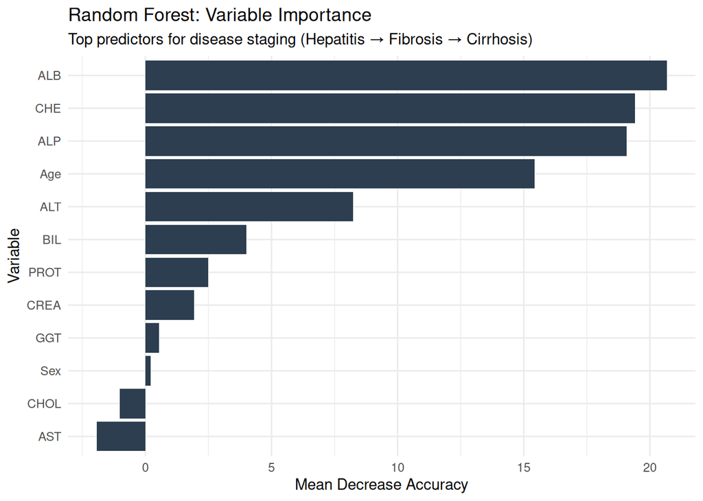

```r
# Variable importance plot
importance_df <- as.data.frame(importance(rf_model))
importance_df$Variable <- rownames(importance_df)

p_rf_imp <- ggplot(importance_df,
                   aes(x = reorder(Variable, MeanDecreaseAccuracy),
                       y = MeanDecreaseAccuracy)) +
  geom_col(fill = "#2C3E50") +
  coord_flip() +
  labs(title = "Random Forest: Variable Importance",
       subtitle = "Top predictors for disease staging (Hepatitis → Fibrosis → Cirrhosis)",
       x = "Variable",
       y = "Mean Decrease Accuracy") +
  theme_minimal()

print(p_rf_imp)
```

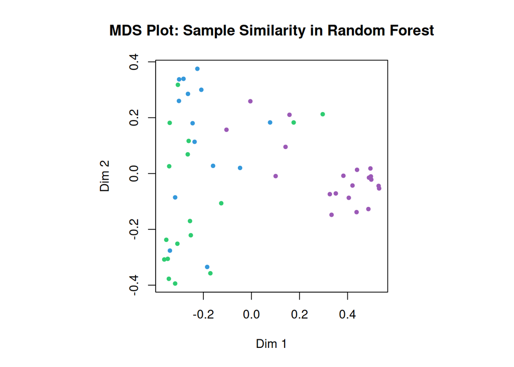

```r
# MDS plot to visualize sample proximity
MDSplot(rf_model, train_rf$Stage,
        palette = c("#2ECC71", "#3498DB", "#9B59B6"),
        main = "MDS Plot: Sample Similarity in Random Forest")
```

```r
ggsave(file.path('figures/', "11_rf_var_importance.png"), p_rf_imp, width = 8, height = 8)
png("figures/12_rf_mds_plot.png", width = 800, height = 600)
MDSplot(rf_model, train_rf$Stage,
        palette = c("#2ECC71", "#3498DB", "#9B59B6"),
        main = "MDS Plot: Sample Similarity in Random Forest")

dev.off()
```

*Observations：*

- Random Forest identified the top three predictors for disease staging:ALB, CHE, ALP
- Age and ALT show moderate importance, while BIL, PROT, CREA, GGT, CHOL, AST, and Sex contribute minimally to classification.
- Clinical Interpretation: The three most important variables (ALB, CHE, ALP) represent key aspects of liver function that progressively deteriorate from hepatitis → fibrosis → cirrhosis.

-The MDS plot shows that the model will likely perform well at identifying cirrhosis but struggle to differentiate hepatitis from fibrosis due to overlapping biomarker profiles. This suggests these disease stages represent a continuum rather than discrete categories.

## 6.2 Linear Discriminant Analysis (LDA) —

```r
# Prepare data for LDA
lda_data <- data_staging %>%
  dplyr::select(Stage, Age, Sex, ALB, ALP, ALT, AST, BIL, CHE, CHOL, CREA, GGT, PROT) %>%
  mutate(Stage = factor(Stage, levels = c("Hepatitis", "Fibrosis", "Cirrhosis")),
         Sex = factor(Sex))

# Split data
set.seed(123)
train_idx_lda <- createDataPartition(lda_data$Stage, p = 0.7, list = FALSE)
train_lda <- lda_data[train_idx_lda, ]
test_lda <- lda_data[-train_idx_lda, ]

cat("Training set size:", nrow(train_lda), "\n")
```

```
## Training set size: 51
```

```r
cat("Testing set size:", nrow(test_lda), "\n")
```

```
## Testing set size: 21
```

```r
# Train LDA model
lda_model <- lda(Stage ~ ., data = train_lda)
print(lda_model)
```

```
## Call:
## lda(Stage ~ ., data = train_lda)
##
## Prior probabilities of groups:
## Hepatitis  Fibrosis Cirrhosis
## 0.3333333 0.2745098 0.3921569
##
## Group means:
##                Age      Sexm      ALB       ALP      ALT      AST      BIL
## Hepatitis 39.23529 0.8235294 43.17647  41.25294 21.94118 81.81765 16.64706
## Fibrosis  51.28571 0.6428571 42.57143  38.17500 57.14286 79.82143 14.28571
## Cirrhosis 52.00000 0.6000000 32.65000 101.59500 24.64000 92.92500 51.40000
##                CHE     CHOL      CREA       GGT     PROT
## Hepatitis 8.594118 5.005882  74.76471  98.72353 74.47647
## Fibrosis  7.870000 4.710714  74.99286  74.42143 75.82857
## Cirrhosis 3.819500 3.956000 165.63000 135.89000 69.36000
##
## Coefficients of linear discriminants:
##                LD1           LD2
## Age  -0.0109389334 -0.1091399258
## Sexm  0.2152894960  0.4297140437
## ALB  -0.1210841129 -0.1139543950
## ALP   0.0092409203 -0.0003836504
## ALT   0.0033262082 -0.0117231269
## AST  -0.0040177139 -0.0019275692
## BIL   0.0030397038 -0.0003869605
## CHE  -0.3062503685  0.0301239057
## CHOL -0.0848697934  0.1027467080
## CREA  0.0019417977 -0.0011201617
## GGT  -0.0006766128  0.0034255790
## PROT  0.0090774840  0.0247756557
##
## Proportion of trace:
##    LD1    LD2
## 0.8327 0.1673
```

```r
# Predictions and evaluation
lda_pred <- predict(lda_model, test_lda)
cm_lda <- confusionMatrix(lda_pred$class, test_lda$Stage)
print(cm_lda)
```

```
## Confusion Matrix and Statistics
##
##            Reference
## Prediction  Hepatitis Fibrosis Cirrhosis
##   Hepatitis         6        2         0
##   Fibrosis          1        4         3
##   Cirrhosis         0        0         5
##
## Overall Statistics
##
##                Accuracy : 0.7143
##                  95% CI : (0.4782, 0.8872)
##     No Information Rate : 0.381
##     P-Value [Acc > NIR] : 0.002017
##
##                   Kappa : 0.5758
##
##  Mcnemar's Test P-Value : NA
##
## Statistics by Class:
##
##                      Class: Hepatitis Class: Fibrosis Class: Cirrhosis
## Sensitivity                    0.8571          0.6667           0.6250
## Specificity                    0.8571          0.7333           1.0000
## Pos Pred Value                 0.7500          0.5000           1.0000
## Neg Pred Value                 0.9231          0.8462           0.8125
## Prevalence                     0.3333          0.2857           0.3810
## Detection Rate                 0.2857          0.1905           0.2381
## Detection Prevalence           0.3810          0.3810           0.2381
## Balanced Accuracy              0.8571          0.7000           0.8125
```

*Observation：*

- LD1 captures 83.3% of between-class variance, serving as the primary discriminator
- LD2 captures 16.7% of variance, providing secondary separation
- The negative coefficients of ALB, CHE and CHOL indicate these variables decrease as disease progresses from hepatitis → fibrosis → cirrhosis, aligning with the LD1 score pattern.
- LDA confirms that CHE and ALB are the most important biomarkers for disease staging, consistent with Random Forest findings. -The model achieves reasonable accuracy (71.4%) but struggles with intermediate disease stages, suggesting that additional features or longitudinal data may be needed for improved staging classification.

### 6.2.1 LDA Coefficients

```r
cat("\nLinear Discriminant 1 Coefficients (sorted by magnitude):\n")
```

```
##
## Linear Discriminant 1 Coefficients (sorted by magnitude):
```

```r
coef_ld1 <- sort(lda_model$scaling[, 1], decreasing = TRUE)
print(coef_ld1)
```

```
##          Sexm           ALP          PROT           ALT           BIL
##  0.2152894960  0.0092409203  0.0090774840  0.0033262082  0.0030397038
##          CREA           GGT           AST           Age          CHOL
##  0.0019417977 -0.0006766128 -0.0040177139 -0.0109389334 -0.0848697934
##           ALB           CHE
## -0.1210841129 -0.3062503685
```

```r
cat("\nLinear Discriminant 2 Coefficients (sorted by magnitude):\n")
```

```
##
## Linear Discriminant 2 Coefficients (sorted by magnitude):
```

```r
coef_ld2 <- sort(lda_model$scaling[, 2], decreasing = TRUE)
print(coef_ld2)
```

```
##          Sexm          CHOL           CHE          PROT           GGT
##  0.4297140437  0.1027467080  0.0301239057  0.0247756557  0.0034255790
##           ALP           BIL          CREA           AST           ALT
## -0.0003836504 -0.0003869605 -0.0011201617 -0.0019275692 -0.0117231269
##           Age           ALB
## -0.1091399258 -0.1139543950
```

### 6.2.2 LD1 Distribution Plot

```r
cat("Saving 09_lda_ld1_distribution.png ...\n")
```

```
## Saving 09_lda_ld1_distribution.png ...
```

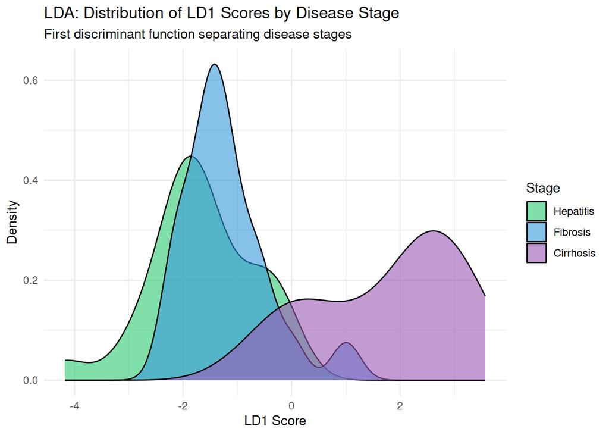

```r
lda_values <- as.data.frame(predict(lda_model, lda_data)$x)
lda_values$Stage <- lda_data$Stage

p_lda_ld1 <- ggplot(lda_values, aes(x = LD1, fill = Stage)) +
  geom_density(alpha = 0.6) +
  scale_fill_manual(values = c("Hepatitis" = "#2ECC71",
                               "Fibrosis" = "#3498DB",
                               "Cirrhosis" = "#9B59B6")) +
  labs(title = "LDA: Distribution of LD1 Scores by Disease Stage",
       subtitle = "First discriminant function separating disease stages",
       x = "LD1 Score",
       y = "Density") +
  theme_minimal()

print(p_lda_ld1)
```

```r
png("figures/13_lda_ld1_distribution.png", width = 800, height = 600)
print(p_lda_ld1)
dev.off()
```

**Observations:**

**Interpretation:**

- LD1 effectively captures disease severity progression along a single axis. Cirrhosis is well-distinguished, but the overlap between hepatitis and fibrosis explains the classification challenges seen in the confusion matrix.

### 6.2.3 LDA Scatter Plot (LD1 vs LD2)

```r
cat("Saving 10_lda_scatter.png ...\n")
```

```
## Saving 10_lda_scatter.png ...
```

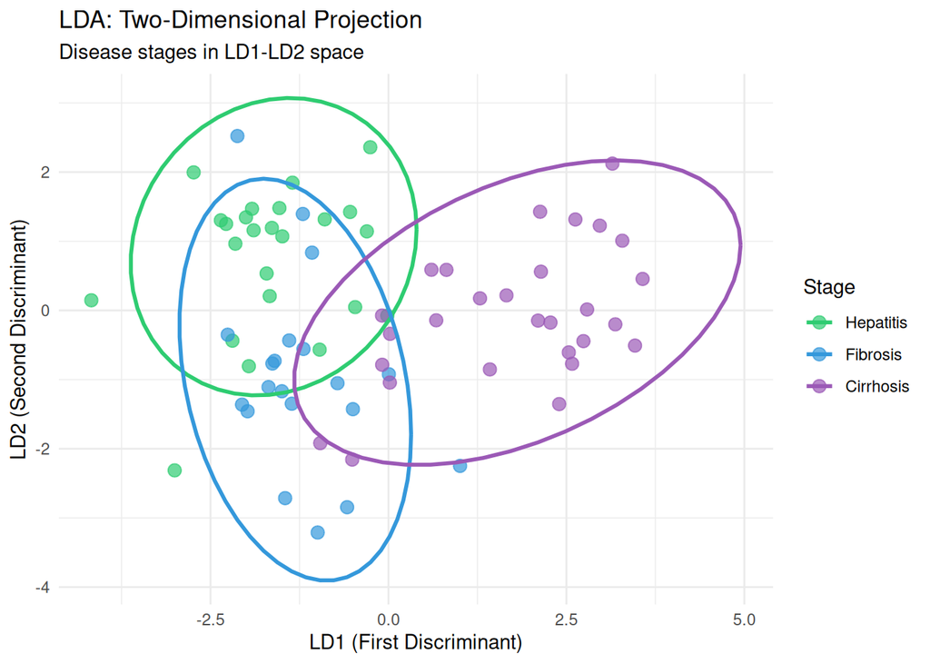

```r
p_lda_scatter <- ggplot(lda_values, aes(x = LD1, y = LD2, color = Stage)) +
  geom_point(alpha = 0.7, size = 3) +
  stat_ellipse(level = 0.95, linewidth = 1) +
  scale_color_manual(values = c("Hepatitis" = "#2ECC71",
                                "Fibrosis" = "#3498DB",
                                "Cirrhosis" = "#9B59B6")) +
  labs(title = "LDA: Two-Dimensional Projection",
       subtitle = "Disease stages in LD1-LD2 space",
       x = "LD1 (First Discriminant)",
       y = "LD2 (Second Discriminant)") +
  theme_minimal() +
  theme(legend.position = "right")

print(p_lda_scatter)
```

```r
png("figures/14_lda_scatter.png", width = 800, height = 600)
print(p_lda_scatter)
dev.off()
```

**Observations:**

- Cirrhosis cluster (purple): Well-separated on the right (positive LD1), with minimal overlap with other stages
- Hepatitis cluster (green): Concentrated in the left-center region (negative LD1), but extends into fibrosis territory
- Fibrosis cluster (blue): Acts as a “bridge” between hepatitis and cirrhosis, with substantial overlap with both groups
- Several fibrosis samples fall within or near the cirrhosis ellipse, explaining the misclassifications in the confusion matrix

**Interpretation:** - The two-dimensional projection confirms that fibrosis represents a transitional stage rather than a discrete category. While LD1 captures the primary disease progression axis, LD2 adds limited additional separation, consistent with it explaining only 16.7% of variance. The visualization supports the conclusion that three-class staging is inherently difficult due to the continuum nature of liver disease progression.

## 7. Conclusion and Limitation

### 7.2 Limitation and Future Directions

**Future Directions：**

- Addressing class imbalance through techniques such as SMOTE (Synthetic Minority Over-sampling Technique), ensemble methods with balanced class weights, or stratified sampling strategies could improve sensitivity for disease detection.
- Incorporating longitudinal data would enable analysis of biomarker trajectories over time (e.g., rate of ALB decline, AST elevation patterns), which may prove more informative for disease staging and progression prediction than single time-point measurements. Integrating multimodal data including imaging features (ultrasound, CT, MRI), clinical variables (age, comorbidities, medication history), genetic markers, and viral characteristics could provide a more comprehensive disease profile and improve staging accuracy.
- Reframing the staging problem as either a binary classification (early vs advanced disease) or a regression task (predicting continuous disease severity scores) rather than forcing three discrete categories might better reflect the biological reality of disease progression.
- Finally, prospective studies could evaluate whether these biomarker-based models can guide clinical decision-making, improve patient outcomes, or reduce healthcare costs in real-world screening programs.